# Day 1 ANSWER SCRIPT: Self-guided practical - Using R for linear regression and GLMs

Andrew Parnell

## Task set 1: linear regression

The `airquality` data set is included with R. You can find a description of the data at `help(airquality)` and can get at it simply by typing `airquality` at the R command prompt. Let’s suppose we’re interested in predicting the variable `Ozone` from the other variables

Tasks:

1. First create some plots of the variables and make sure you understand the relationship between them. Hint: A good start can be found in the `help(airquality)` file (see the example at the bottom of that page).

```r
str(airquality)
```

```
## 'data.frame':    153 obs. of  6 variables:
##  $ Ozone  : int  41 36 12 18 NA 28 23 19 8 NA ...
##  $ Solar.R: int  190 118 149 313 NA NA 299 99 19 194 ...
##  $ Wind   : num  7.4 8 12.6 11.5 14.3 14.9 8.6 13.8 20.1 8.6 ...
##  $ Temp   : int  67 72 74 62 56 66 65 59 61 69 ...
##  $ Month  : int  5 5 5 5 5 5 5 5 5 5 ...
##  $ Day    : int  1 2 3 4 5 6 7 8 9 10 ...
```

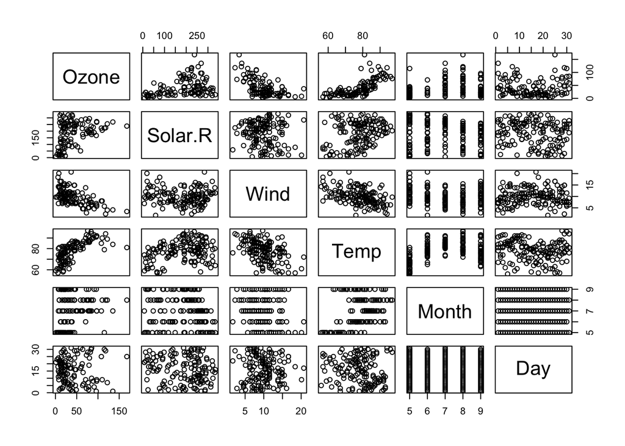

```r
pairs(airquality) # Sees to be interesting relationship between wind, temp and ozone. Less obvious relationship between Solar and Ozone. Unsurprisingly relationship between month and temp non-linear
```

1. Fit a linear regression model using `lm` with `Ozone` as the response and all the other variables as covariates. Use the `summary` method to interpret your findings. (Note that R here is automatically removing rows with missing variables)

```r
mod_1 = lm(Ozone ~ ., data = airquality)
summary(mod_1) # 'significant' variables are solr, wind, temp, month. Month being treated incorrectly? Perhaps should be input as a factor?
```

```
##
## Call:
## lm(formula = Ozone ~ ., data = airquality)
##
## Residuals:
##     Min      1Q  Median      3Q     Max
## -37.014 -12.284  -3.302   8.454  95.348
##
## Coefficients:
##              Estimate Std. Error t value Pr(>|t|)
## (Intercept) -64.11632   23.48249  -2.730  0.00742
## Solar.R       0.05027    0.02342   2.147  0.03411
## Wind         -3.31844    0.64451  -5.149 1.23e-06
## Temp          1.89579    0.27389   6.922 3.66e-10
## Month        -3.03996    1.51346  -2.009  0.04714
## Day           0.27388    0.22967   1.192  0.23576
##
## (Intercept) **
## Solar.R     *
## Wind        ***
## Temp        ***
## Month       *
## Day
## ---
## Signif. codes:
## 0 '***' 0.001 '**' 0.01 '*' 0.05 '.' 0.1 ' ' 1
##
## Residual standard error: 20.86 on 105 degrees of freedom
##   (42 observations deleted due to missingness)
## Multiple R-squared:  0.6249, Adjusted R-squared:  0.6071
## F-statistic: 34.99 on 5 and 105 DF,  p-value: < 2.2e-16
```

1. Have a look at the residuals of the model (e.g. histograms and QQ-plots). Does the model fit well?

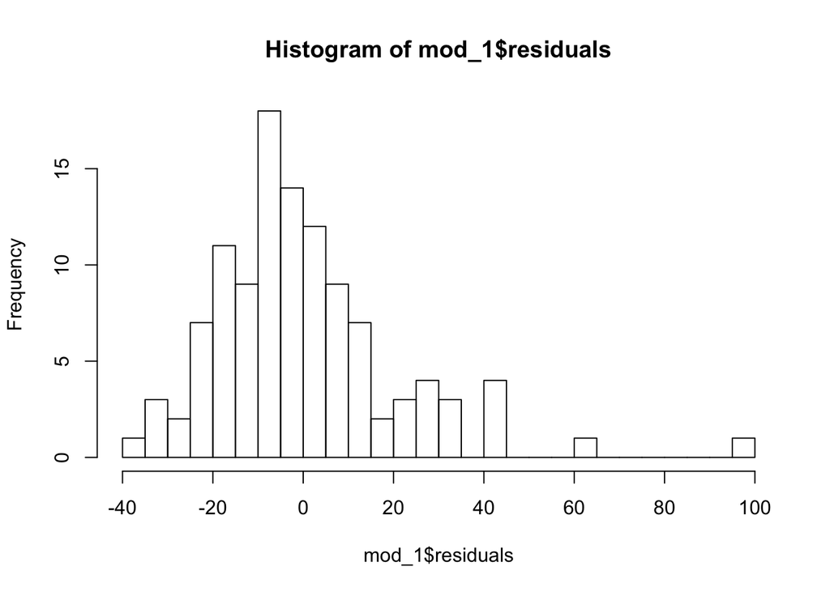

```r
# Histogram and qq plot of residuals
hist(mod_1$residuals, breaks = 30) #A bit skewed
```

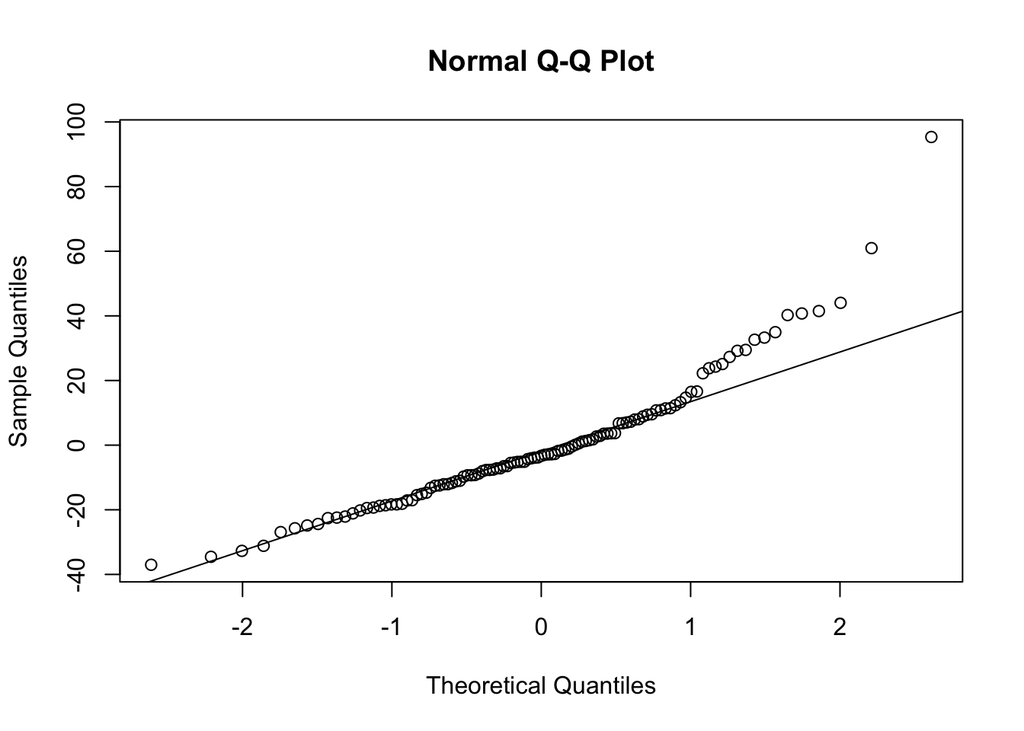

```r
qqnorm(mod_1$residuals)
qqline(mod_1$residuals) # Not great at the top end
```

1. Try another model but this time using the log of Ozone instead. Does it fit better?

```r
mod_2 = lm(log(Ozone) ~ ., data = airquality)
summary(mod_2) # Now only solar, wind and temp.
```

```
##
## Call:
## lm(formula = log(Ozone) ~ ., data = airquality)
##
## Residuals:
##      Min       1Q   Median       3Q      Max
## -2.12941 -0.29248 -0.00188  0.28498  1.15883
##
## Coefficients:
##               Estimate Std. Error t value
## (Intercept) -0.2773962  0.5737028  -0.484
## Solar.R      0.0023988  0.0005721   4.193
## Wind        -0.0613804  0.0157461  -3.898
## Temp         0.0522667  0.0066914   7.811
## Month       -0.0378341  0.0369754  -1.023
## Day          0.0042116  0.0056111   0.751
##             Pr(>|t|)
## (Intercept) 0.629734
## Solar.R     5.77e-05 ***
## Wind        0.000171 ***
## Temp        4.53e-12 ***
## Month       0.308554
## Day         0.454583
## ---
## Signif. codes:
## 0 '***' 0.001 '**' 0.01 '*' 0.05 '.' 0.1 ' ' 1
##
## Residual standard error: 0.5096 on 105 degrees of freedom
##   (42 observations deleted due to missingness)
## Multiple R-squared:  0.6694, Adjusted R-squared:  0.6536
## F-statistic: 42.51 on 5 and 105 DF,  p-value: < 2.2e-16
```

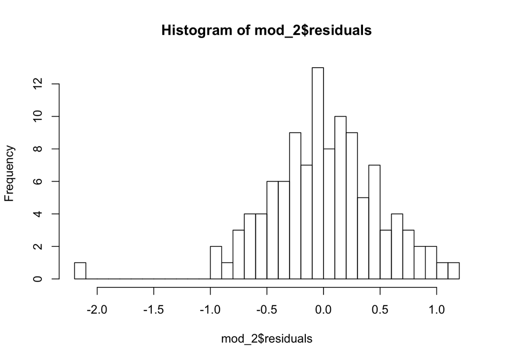

```r
hist(mod_2$residuals, breaks = 30) # Much better - still one weird value
```

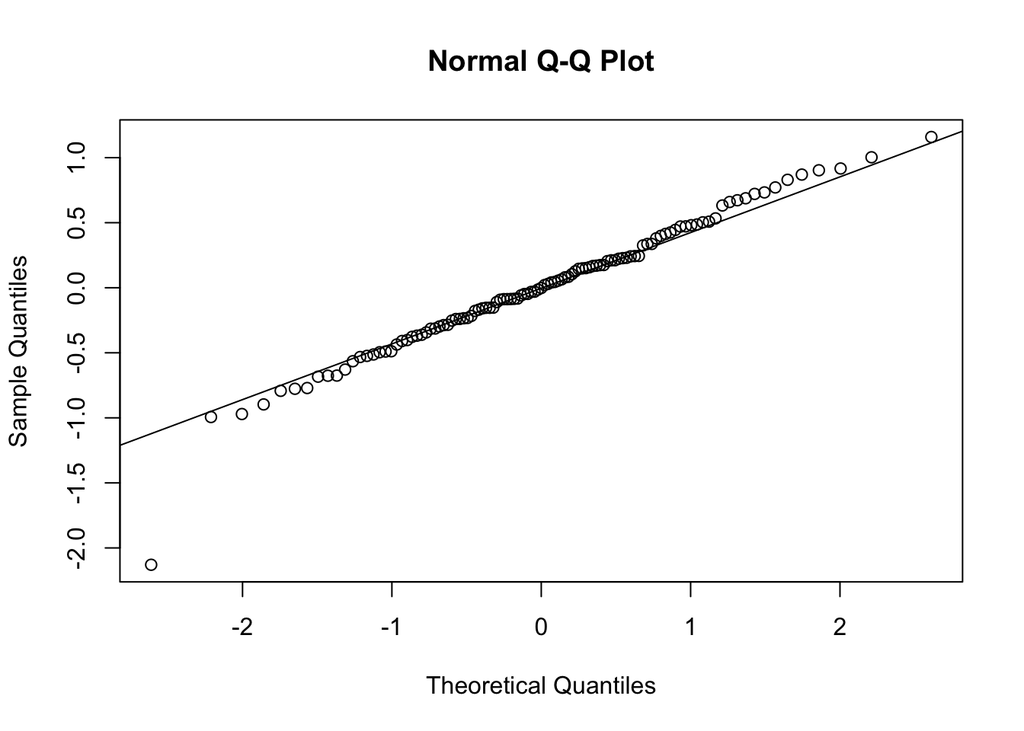

```r
qqnorm(mod_2$residuals)
qqline(mod_2$residuals) # Much better - apart from one
```

1. Identify the one strange observation and see if you can work out what happened that day

```r
which.min(mod_2$residuals) # Is it observations 17 or 21???
```

```
## 21
## 17
```

```r
airquality[c(17,21),] # It's definitely observation 21. Has an Ozone value of 1. Possibly incorrect?
```

```
##    Ozone Solar.R Wind Temp Month Day
## 17    34     307 12.0   66     5  17
## 21     1       8  9.7   59     5  21
```

1. You can get the AIC of this model with e.g. `AIC(my_model)`. Recall that lower AIC means a better model. Try some more models and see if you can get a lower AIC value. Some ideas might include: interactions between terms (e.g. include `+ Wind*Temp`), quadratic functions (e.g. include `+ I(Wind^2)`), and changing month and day to be factor rather than numerical variables.

```r
AIC(mod_2) # 173.1773
```

```
## [1] 173.1773
```

```r
# Try some other models
mod_3 = lm(log(Ozone) ~ .*., data = airquality) # All 2-way interactions
summary(mod_3)
```

```
##
## Call:
## lm(formula = log(Ozone) ~ . * ., data = airquality)
##
## Residuals:
##      Min       1Q   Median       3Q      Max
## -1.96680 -0.29278 -0.03529  0.27074  1.16273
##
## Coefficients:
##                 Estimate Std. Error t value
## (Intercept)   -2.962e+00  4.000e+00  -0.740
## Solar.R        3.555e-03  6.784e-03   0.524
## Wind           1.354e-01  1.445e-01   0.937
## Temp           9.341e-02  5.287e-02   1.767
## Month          4.381e-02  4.662e-01   0.094
## Day           -3.190e-02  7.588e-02  -0.420
## Solar.R:Wind  -1.013e-04  1.955e-04  -0.518
## Solar.R:Temp  -1.504e-05  8.474e-05  -0.178
## Solar.R:Month  1.061e-04  4.255e-04   0.249
## Solar.R:Day    2.120e-05  8.241e-05   0.257
## Wind:Temp     -2.886e-03  2.080e-03  -1.387
## Wind:Month     3.440e-03  1.272e-02   0.271
## Wind:Day       1.362e-03  2.119e-03   0.643
## Temp:Month    -1.908e-03  5.205e-03  -0.367
## Temp:Day       2.235e-04  9.195e-04   0.243
## Month:Day      2.556e-04  5.128e-03   0.050
##               Pr(>|t|)
## (Intercept)     0.4608
## Solar.R         0.6015
## Wind            0.3510
## Temp            0.0805 .
## Month           0.9253
## Day             0.6751
## Solar.R:Wind    0.6054
## Solar.R:Temp    0.8595
## Solar.R:Month   0.8036
## Solar.R:Day     0.7975
## Wind:Temp       0.1686
## Wind:Month      0.7873
## Wind:Day        0.5220
## Temp:Month      0.7147
## Temp:Day        0.8085
## Month:Day       0.9604
## ---
## Signif. codes:
## 0 '***' 0.001 '**' 0.01 '*' 0.05 '.' 0.1 ' ' 1
##
## Residual standard error: 0.5211 on 95 degrees of freedom
##   (42 observations deleted due to missingness)
## Multiple R-squared:  0.6872, Adjusted R-squared:  0.6379
## F-statistic: 13.92 on 15 and 95 DF,  p-value: < 2.2e-16
```

```r
AIC(mod_3) # 187.0112
```

```
## [1] 187.0112
```

```r
mod_4 = lm(log(Ozone) ~ (.*.)^3, data = airquality) # All 3-way interactions
summary(mod_4)
```

```
##
## Call:
## lm(formula = log(Ozone) ~ (. * .)^3, data = airquality)
##
## Residuals:
##      Min       1Q   Median       3Q      Max
## -1.40242 -0.22194 -0.00753  0.24366  1.39709
##
## Coefficients:
##                               Estimate Std. Error
## (Intercept)                 -4.453e+01  5.200e+01
## Solar.R                      2.367e-01  2.782e-01
## Wind                         7.673e+00  4.649e+00
## Temp                         7.372e-01  6.941e-01
## Month                        9.724e+00  8.880e+00
## Day                          1.752e+00  2.982e+00
## Solar.R:Wind                -3.160e-02  2.523e-02
## Solar.R:Temp                -3.442e-03  3.633e-03
## Solar.R:Month               -5.018e-02  4.678e-02
## Solar.R:Day                 -1.273e-02  1.674e-02
## Wind:Temp                   -1.150e-01  6.210e-02
## Wind:Month                  -1.350e+00  8.335e-01
## Wind:Day                    -4.049e-01  2.621e-01
## Temp:Month                  -1.357e-01  1.109e-01
## Temp:Day                    -3.168e-02  4.278e-02
## Month:Day                   -4.454e-01  4.530e-01
## Solar.R:Wind:Temp            4.616e-04  3.284e-04
## Solar.R:Wind:Month           5.691e-03  4.389e-03
## Solar.R:Wind:Day             1.923e-03  1.471e-03
## Solar.R:Temp:Month           6.785e-04  5.859e-04
## Solar.R:Temp:Day             1.987e-04  2.311e-04
## Solar.R:Month:Day            2.704e-03  2.460e-03
## Wind:Temp:Month              1.888e-02  1.037e-02
## Wind:Temp:Day                6.452e-03  3.825e-03
## Wind:Month:Day               7.202e-02  4.043e-02
## Temp:Month:Day               6.747e-03  6.159e-03
## Solar.R:Wind:Temp:Month     -7.825e-05  5.479e-05
## Solar.R:Wind:Temp:Day       -2.940e-05  2.047e-05
## Solar.R:Wind:Month:Day      -3.372e-04  2.185e-04
## Solar.R:Temp:Month:Day      -3.845e-05  3.283e-05
```

[output cut: 28 more lines]

```
## Temp:Month:Day                1.095   0.2767
## Solar.R:Wind:Temp:Month      -1.428   0.1572
## Solar.R:Wind:Temp:Day        -1.436   0.1549
## Solar.R:Wind:Month:Day       -1.543   0.1268
## Solar.R:Temp:Month:Day       -1.171   0.2451
## Wind:Temp:Month:Day          -1.933   0.0568 .
## Solar.R:Wind:Temp:Month:Day   1.665   0.1000 .
## ---
## Signif. codes:
## 0 '***' 0.001 '**' 0.01 '*' 0.05 '.' 0.1 ' ' 1
##
## Residual standard error: 0.4921 on 79 degrees of freedom
##   (42 observations deleted due to missingness)
## Multiple R-squared:  0.768,  Adjusted R-squared:  0.677
## F-statistic: 8.436 on 31 and 79 DF,  p-value: 1.129e-14
```

```r
AIC(mod_4) # 185.8515
```

```
## [1] 185.8515
```

```r
# Model with month as a factor
mod_5 = lm(log(Ozone) ~ . - Month + as.factor(Month), data = airquality)
summary(mod_5)
```

```
##
## Call:
## lm(formula = log(Ozone) ~ . - Month + as.factor(Month), data = airquality)
##
## Residuals:
##      Min       1Q   Median       3Q      Max
## -2.13862 -0.27374 -0.00767  0.26599  1.14361
##
## Coefficients:
##                     Estimate Std. Error t value
## (Intercept)       -0.4449430  0.6691203  -0.665
## Solar.R            0.0024432  0.0005871   4.161
## Wind              -0.0592787  0.0163748  -3.620
## Temp               0.0519251  0.0085317   6.086
## Day                0.0035922  0.0057353   0.626
## as.factor(Month)6 -0.1597722  0.2263292  -0.706
## as.factor(Month)7 -0.1087654  0.1954027  -0.557
## as.factor(Month)8 -0.0395237  0.2038328  -0.194
## as.factor(Month)9 -0.1970522  0.1652345  -1.193
##                   Pr(>|t|)
## (Intercept)        0.50757
## Solar.R           6.62e-05 ***
## Wind               0.00046 ***
## Temp              2.05e-08 ***
## Day                0.53250
## as.factor(Month)6  0.48184
## as.factor(Month)7  0.57900
## as.factor(Month)8  0.84664
## as.factor(Month)9  0.23581
## ---
## Signif. codes:
## 0 '***' 0.001 '**' 0.01 '*' 0.05 '.' 0.1 ' ' 1
##
## Residual standard error: 0.5141 on 102 degrees of freedom
##   (42 observations deleted due to missingness)
## Multiple R-squared:  0.6732, Adjusted R-squared:  0.6475
## F-statistic: 26.26 on 8 and 102 DF,  p-value: < 2.2e-16
```

```r
AIC(mod_5) # 177.8937
```

```
## [1] 177.8937
```

```r
# Model without day
mod_6 = lm(log(Ozone) ~ . - Day - Month + as.factor(Month), data = airquality)
summary(mod_6)
```

```
##
## Call:
## lm(formula = log(Ozone) ~ . - Day - Month + as.factor(Month),
##     data = airquality)
##
## Residuals:
##      Min       1Q   Median       3Q      Max
## -2.12662 -0.28197 -0.02742  0.28834  1.16785
##
## Coefficients:
##                     Estimate Std. Error t value
## (Intercept)       -0.3392540  0.6455802  -0.526
## Solar.R            0.0024410  0.0005854   4.170
## Wind              -0.0592068  0.0163260  -3.627
## Temp               0.0511975  0.0084272   6.075
## as.factor(Month)6 -0.1575432  0.2256326  -0.698
## as.factor(Month)7 -0.0952694  0.1936372  -0.492
## as.factor(Month)8 -0.0228939  0.2014990  -0.114
## as.factor(Month)9 -0.1929045  0.1646140  -1.172
##                   Pr(>|t|)
## (Intercept)       0.600363
## Solar.R           6.36e-05 ***
## Wind              0.000449 ***
## Temp              2.10e-08 ***
## as.factor(Month)6 0.486607
## as.factor(Month)7 0.623767
## as.factor(Month)8 0.909762
## as.factor(Month)9 0.243957
## ---
## Signif. codes:
## 0 '***' 0.001 '**' 0.01 '*' 0.05 '.' 0.1 ' ' 1
##
## Residual standard error: 0.5125 on 103 degrees of freedom
##   (42 observations deleted due to missingness)
## Multiple R-squared:  0.6719, Adjusted R-squared:  0.6496
## F-statistic: 30.13 on 7 and 103 DF,  p-value: < 2.2e-16
```

```r
AIC(mod_6) # 176.3198 # Very slightly 'better'
```

```
## [1] 176.3198
```

## Task set 2: logistic regression

1. Load in the `horseshoe.csv` data set from the data directory and familiarise yourself with the data structure from the `data_description.txt` file

```r
horseshoe = read.csv('../data/horseshoe.csv')
str(horseshoe)
```

```
## 'data.frame':    173 obs. of  5 variables:
##  $ color : int  2 3 1 3 3 2 1 3 2 3 ...
##  $ spine : int  3 3 1 3 3 3 1 2 1 3 ...
##  $ width : num  28.3 22.5 26 24.8 26 23.8 26.5 24.7 23.7 25.6 ...
##  $ satell: int  8 0 9 0 4 0 0 0 0 0 ...
##  $ weight: num  3.05 1.55 2.3 2.1 2.6 2.1 2.35 1.9 1.95 2.15 ...
```

1. Turn the `color` and `spine` variables into factors with their proper names

```r
horseshoe$color_fac = factor(horseshoe$color,
                             labels = c('light medium', 'medium',
                                        'dark medium', 'dark'))
horseshoe$spine_fac = factor(horseshoe$spine,
                             labels = c('both good',
                                        'one worn or broken',
                                        'both worn or broken'))
```

1. Familiarise yourself by plotting the data and exploring the structure between the variables

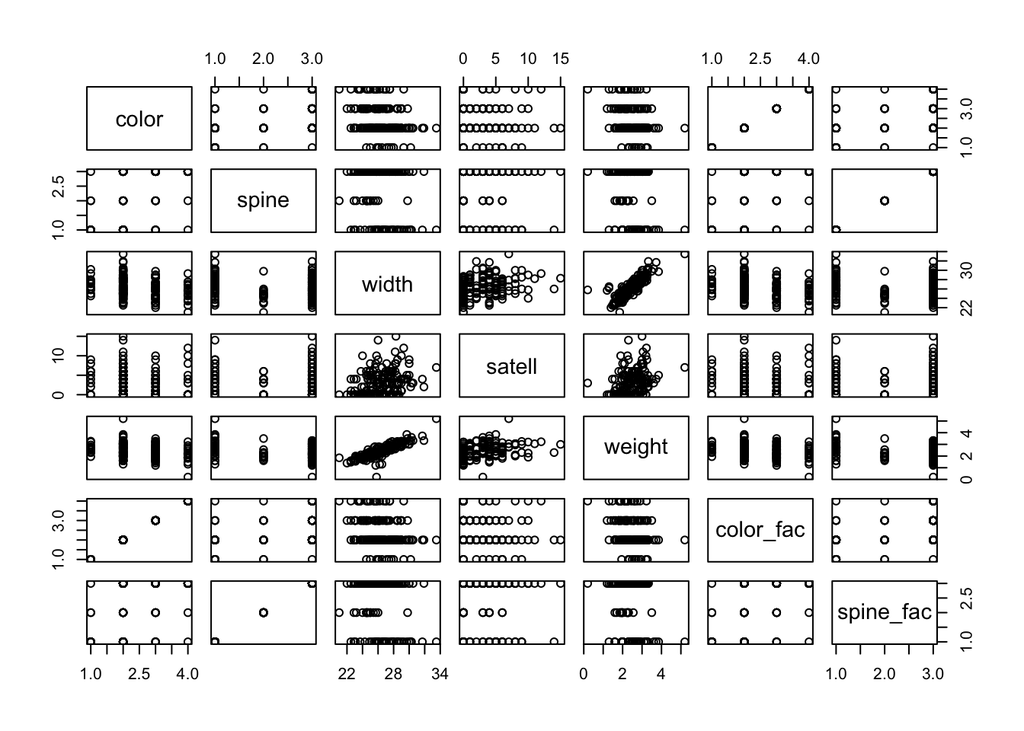

```r
pairs(horseshoe) # Strong relationship between width and weight
```

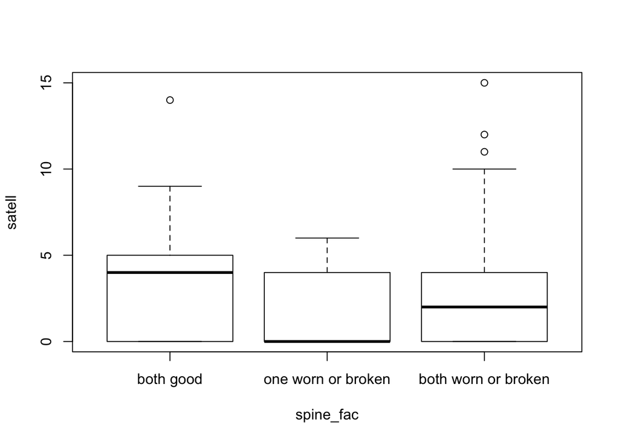

```r
# Response variable is satell so perhaps explore more
boxplot(satell ~ spine_fac, data = horseshoe)
```

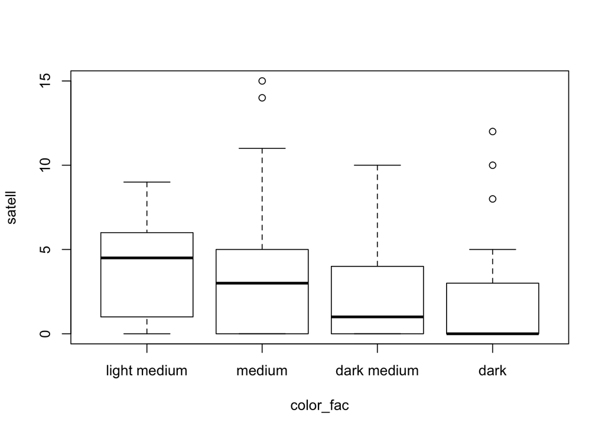

```r
boxplot(satell ~ color_fac, data = horseshoe)
```

1. Create a binary variable which contains only whether the satellite variable is >0 or not. We will use this as our response variable. Create a plot which shows the relationship of this variable with `width`.

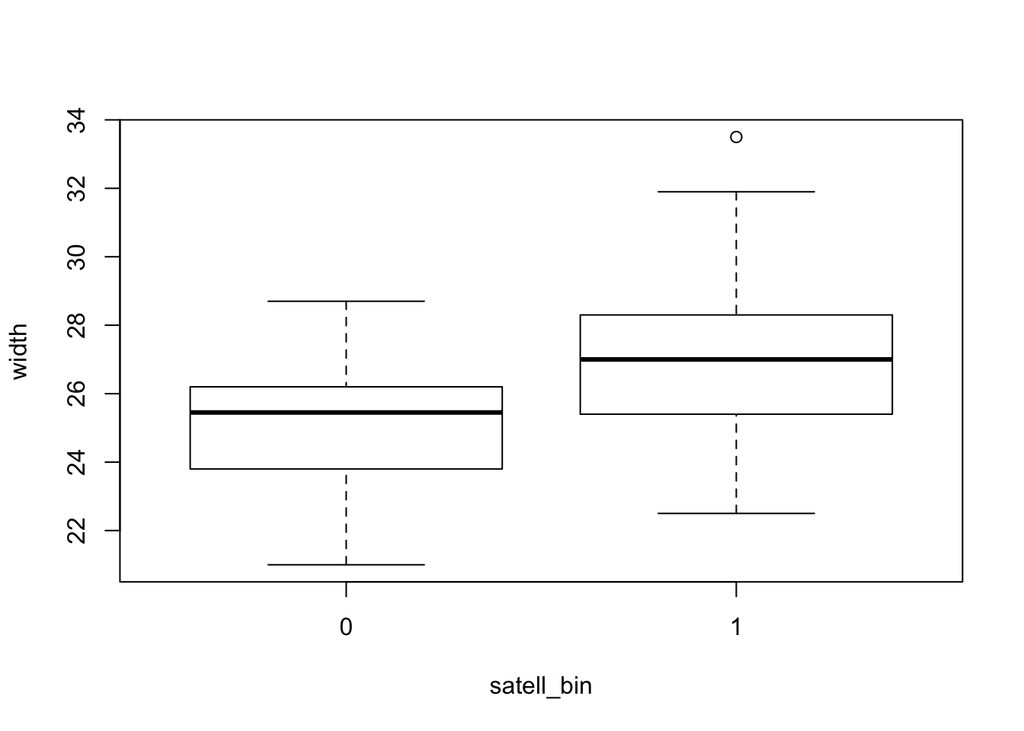

```r
horseshoe$satell_bin = as.integer(horseshoe$satell > 0)
boxplot(width ~ satell_bin, data = horseshoe) # Higher width with satell > 0
```

1. Fit a binomial glm (a logistic regression) with the binary variable as the response and `width` as a covariate. Summarise your findings

```r
logistic_mod = glm(satell_bin ~ width, data = horseshoe,
                   family = 'binomial')
summary(logistic_mod)
```

```
##
## Call:
## glm(formula = satell_bin ~ width, family = "binomial", data = horseshoe)
##
## Deviance Residuals:
##     Min       1Q   Median       3Q      Max
## -2.0281  -1.0458   0.5480   0.9066   1.6942
##
## Coefficients:
##             Estimate Std. Error z value Pr(>|z|)
## (Intercept) -12.3508     2.6287  -4.698 2.62e-06
## width         0.4972     0.1017   4.887 1.02e-06
##
## (Intercept) ***
## width       ***
## ---
## Signif. codes:
## 0 '***' 0.001 '**' 0.01 '*' 0.05 '.' 0.1 ' ' 1
##
## (Dispersion parameter for binomial family taken to be 1)
##
##     Null deviance: 225.76  on 172  degrees of freedom
## Residual deviance: 194.45  on 171  degrees of freedom
## AIC: 198.45
##
## Number of Fisher Scoring iterations: 4
```

1. Create a plot of the fitted values on top of a scatter plot of the data (hint: width on x-axis, binary response variable on y-axis)

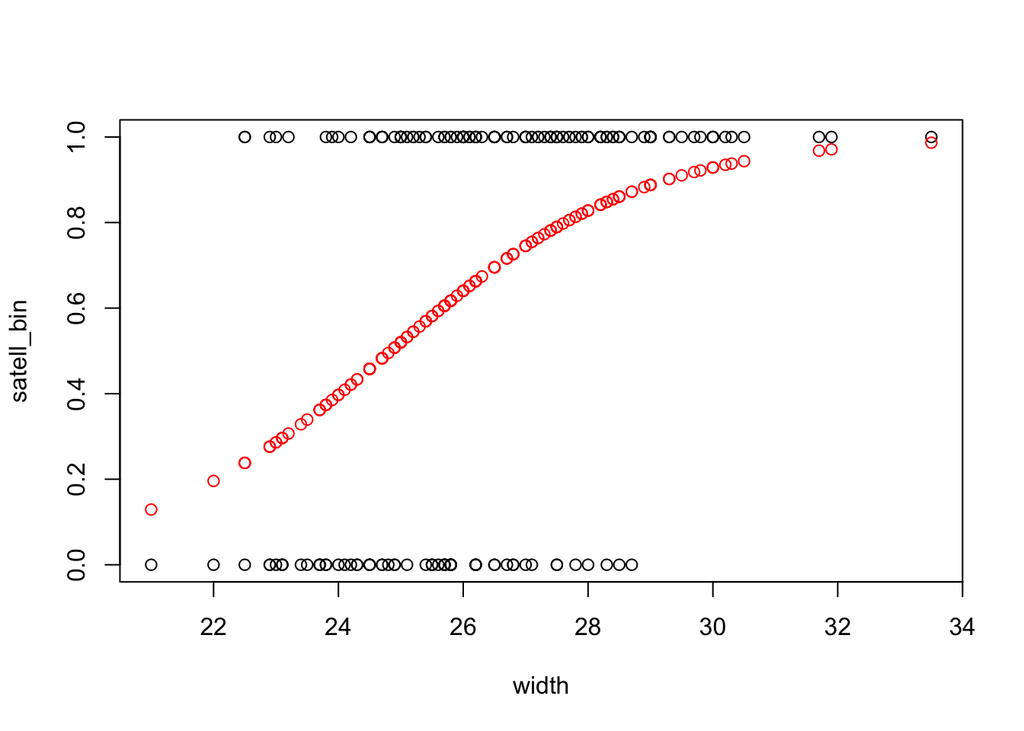

```r
with(horseshoe, plot(width, satell_bin))
points(horseshoe$width, logistic_mod$fitted.values, col = 'red')
```

```r
# Must be able to make this plot look nicer!
```

1. Try fitting some more models to the data with more variables (and perhaps interactions) to see if you can get the AIC lower. Compare your new models’ fitted values to the first model

```r
logistic_mod_2 = glm(satell_bin ~ width + color_fac + spine_fac, data = horseshoe,
                   family = 'binomial')
summary(logistic_mod_2)
```

```
##
## Call:
## glm(formula = satell_bin ~ width + color_fac + spine_fac, family = "binomial",
##     data = horseshoe)
##
## Deviance Residuals:
##     Min       1Q   Median       3Q      Max
## -2.1206  -0.9724   0.5076   0.8750   2.1158
##
## Coefficients:
##                               Estimate Std. Error
## (Intercept)                  -11.09953    2.97706
## width                          0.45624    0.10779
## color_facmedium               -0.14340    0.77838
## color_facdark medium          -0.52405    0.84685
## color_facdark                 -1.66833    0.93285
## spine_facone worn or broken   -0.05782    0.70308
## spine_facboth worn or broken   0.37703    0.50191
##                              z value Pr(>|z|)
## (Intercept)                   -3.728 0.000193 ***
## width                          4.233 2.31e-05 ***
## color_facmedium               -0.184 0.853830
## color_facdark medium          -0.619 0.536030
## color_facdark                 -1.788 0.073706 .
## spine_facone worn or broken   -0.082 0.934453
## spine_facboth worn or broken   0.751 0.452540
## ---
## Signif. codes:
## 0 '***' 0.001 '**' 0.01 '*' 0.05 '.' 0.1 ' ' 1
##
## (Dispersion parameter for binomial family taken to be 1)
##
##     Null deviance: 225.76  on 172  degrees of freedom
## Residual deviance: 186.61  on 166  degrees of freedom
## AIC: 200.61
##
## Number of Fisher Scoring iterations: 4
```

```r
AIC(logistic_mod, logistic_mod_2) # New model not any better
```

```
##                df      AIC
## logistic_mod    2 198.4527
## logistic_mod_2  7 200.6119
```

```r
# Many more modelling options to try here
```

## Task set 3: Poisson and Negative Binomial regression

1. This time fit a Poisson GLM to the horseshoe data, using the original number of satellites rather than the binary version you fitted previously. Again use `width` as the sole covariate, and again plot the fitted values

```r
pois_mod = glm(satell ~ width, data = horseshoe, family = poisson)
summary(pois_mod)
```

```
##
## Call:
## glm(formula = satell ~ width, family = poisson, data = horseshoe)
##
## Deviance Residuals:
##     Min       1Q   Median       3Q      Max
## -2.8526  -1.9884  -0.4933   1.0970   4.9221
##
## Coefficients:
##             Estimate Std. Error z value Pr(>|z|)
## (Intercept) -3.30476    0.54224  -6.095  1.1e-09
## width        0.16405    0.01997   8.216  < 2e-16
##
## (Intercept) ***
## width       ***
## ---
## Signif. codes:
## 0 '***' 0.001 '**' 0.01 '*' 0.05 '.' 0.1 ' ' 1
##
## (Dispersion parameter for poisson family taken to be 1)
##
##     Null deviance: 632.79  on 172  degrees of freedom
## Residual deviance: 567.88  on 171  degrees of freedom
## AIC: 927.18
##
## Number of Fisher Scoring iterations: 6
```

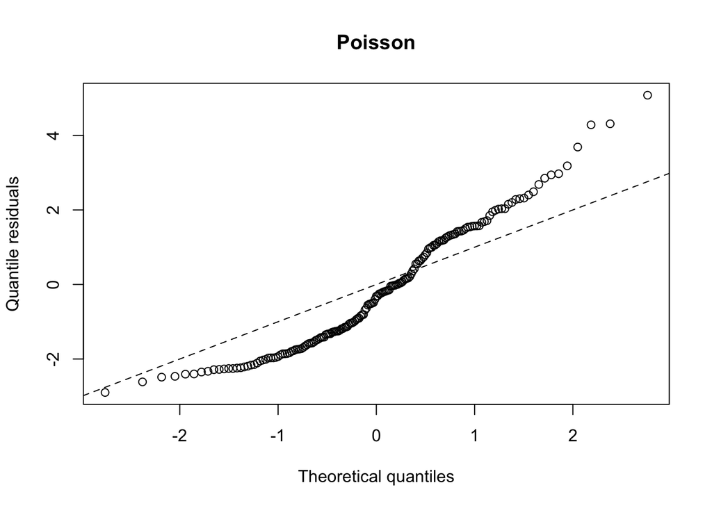

```r
# Example of a qq-plot for a Poisson distribution - bit of a hack!
# qqrplot comes from the countreg package
source('https://raw.githubusercontent.com/rforge/countreg/master/pkg/R/qqrplot.R')
source('https://raw.githubusercontent.com/rforge/countreg/master/pkg/R/qresiduals.R')
qqrplot(pois_mod,
        main = "Poisson")
```

1. Now try a model with all of the covariates (make sure not to include the binary variable you created before). Summarise and see if there’s any improvement. You might notice that more variables are important (compared to the previous binary logistic regression) because we’re using more of the data

```r
pois_mod_2 = glm(satell ~ width + color_fac + spine_fac + weight, data = horseshoe, family = poisson)
summary(pois_mod_2)
```

```
##
## Call:
## glm(formula = satell ~ width + color_fac + spine_fac + weight,
##     family = poisson, data = horseshoe)
##
## Deviance Residuals:
##     Min       1Q   Median       3Q      Max
## -2.9875  -1.9013  -0.5923   0.9464   4.9012
##
## Coefficients:
##                              Estimate Std. Error
## (Intercept)                  -0.84651    0.93057
## width                         0.04531    0.04649
## color_facmedium              -0.25471    0.16809
## color_facdark medium         -0.50104    0.19541
## color_facdark                -0.49764    0.22679
## spine_facone worn or broken  -0.14869    0.21337
## spine_facboth worn or broken  0.07272    0.11941
## weight                        0.38814    0.15693
##                              z value Pr(>|z|)
## (Intercept)                   -0.910   0.3630
## width                          0.975   0.3297
## color_facmedium               -1.515   0.1297
## color_facdark medium          -2.564   0.0103 *
## color_facdark                 -2.194   0.0282 *
## spine_facone worn or broken   -0.697   0.4859
## spine_facboth worn or broken   0.609   0.5425
## weight                         2.473   0.0134 *
## ---
## Signif. codes:
## 0 '***' 0.001 '**' 0.01 '*' 0.05 '.' 0.1 ' ' 1
##
## (Dispersion parameter for poisson family taken to be 1)
##
##     Null deviance: 632.79  on 172  degrees of freedom
## Residual deviance: 552.25  on 165  degrees of freedom
## AIC: 923.55
##
## Number of Fisher Scoring iterations: 6
```

1. A common occurrence is that the Poisson distribution is a poor fit to the data as the mean=variance relationship is rarely met. (You could check if the mean and the variance match for these data). A common alternative is to fit a Negative-Binomial GLM which has an extra parameter to measure excess variance (over-dispersion). The `glm` function doesn’t have this distribution in it by default so you need to call in the MASS library with `library(MASS)`. The command will now be called `glm.nb` which will also try to estimate the over-dispersion parameter (the excess variance over the Poisson). Use `glm.nb` to fit a Negative Binomial GLM to these data, interpret your findings, see if the AIC improves, and plot your output.

```r
library(MASS)
nb_mod = glm.nb(satell ~ width + color_fac + spine_fac + weight, data = horseshoe)
summary(nb_mod)
```

```
##
## Call:
## glm.nb(formula = satell ~ width + color_fac + spine_fac + weight,
##     data = horseshoe, init.theta = 0.9521901429, link = log)
##
## Deviance Residuals:
##     Min       1Q   Median       3Q      Max
## -1.8535  -1.3633  -0.3033   0.4685   2.2238
##
## Coefficients:
##                              Estimate Std. Error
## (Intercept)                  -1.58662    1.83022
## width                         0.07734    0.09053
## color_facmedium              -0.31434    0.37457
## color_facdark medium         -0.57764    0.41921
## color_facdark                -0.53423    0.46877
## spine_facone worn or broken  -0.21439    0.39927
## spine_facboth worn or broken  0.02570    0.24903
## weight                        0.37950    0.31432
##                              z value Pr(>|z|)
## (Intercept)                   -0.867    0.386
## width                          0.854    0.393
## color_facmedium               -0.839    0.401
## color_facdark medium          -1.378    0.168
## color_facdark                 -1.140    0.254
## spine_facone worn or broken   -0.537    0.591
## spine_facboth worn or broken   0.103    0.918
## weight                         1.207    0.227
##
## (Dispersion parameter for Negative Binomial(0.9522) family taken to be 1)
##
##     Null deviance: 219.08  on 172  degrees of freedom
## Residual deviance: 196.73  on 165  degrees of freedom
## AIC: 764.9
##
## Number of Fisher Scoring iterations: 1
##
##
##               Theta:  0.952
##           Std. Err.:  0.173
##
##  2 x log-likelihood:  -746.905
```

```r
AIC(pois_mod, pois_mod_2, nb_mod) # NegBin model way 'better' in terms of AIC
```

```
##            df      AIC
## pois_mod    2 927.1762
## pois_mod_2  8 923.5498
## nb_mod      9 764.9049
```

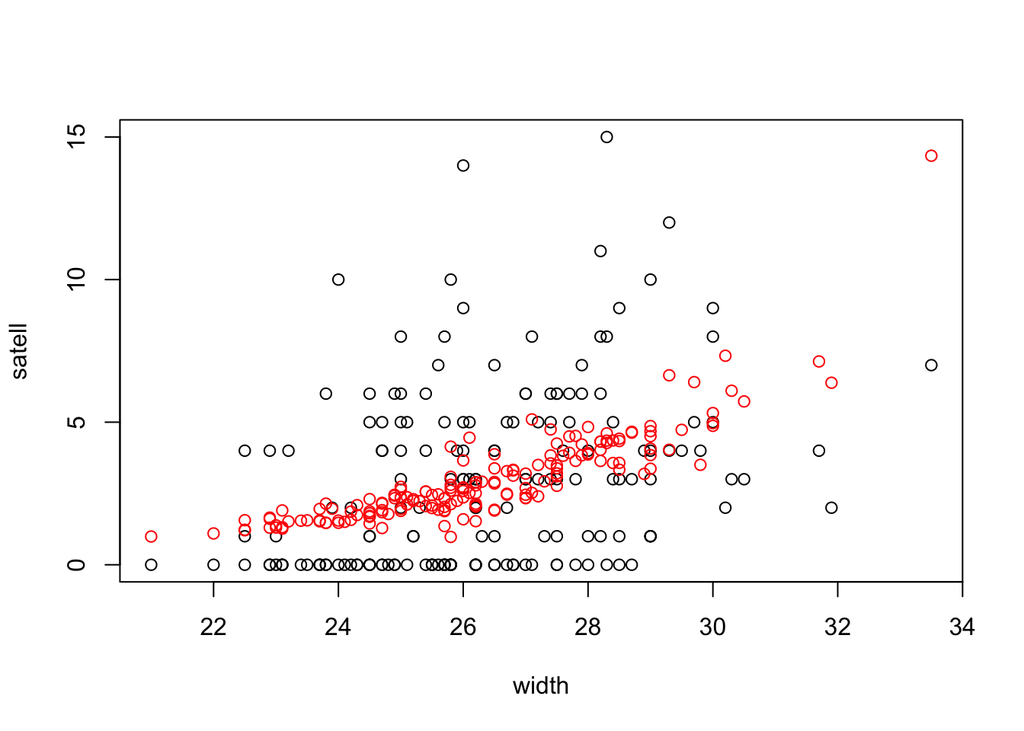

```r
# Plot of fitted values
with(horseshoe, plot(width, satell))
points(horseshoe$width, nb_mod$fitted.values, col = 'red')
```

```r
# Width not the only variable we could plot against (try e.g. color_fac or others)
```

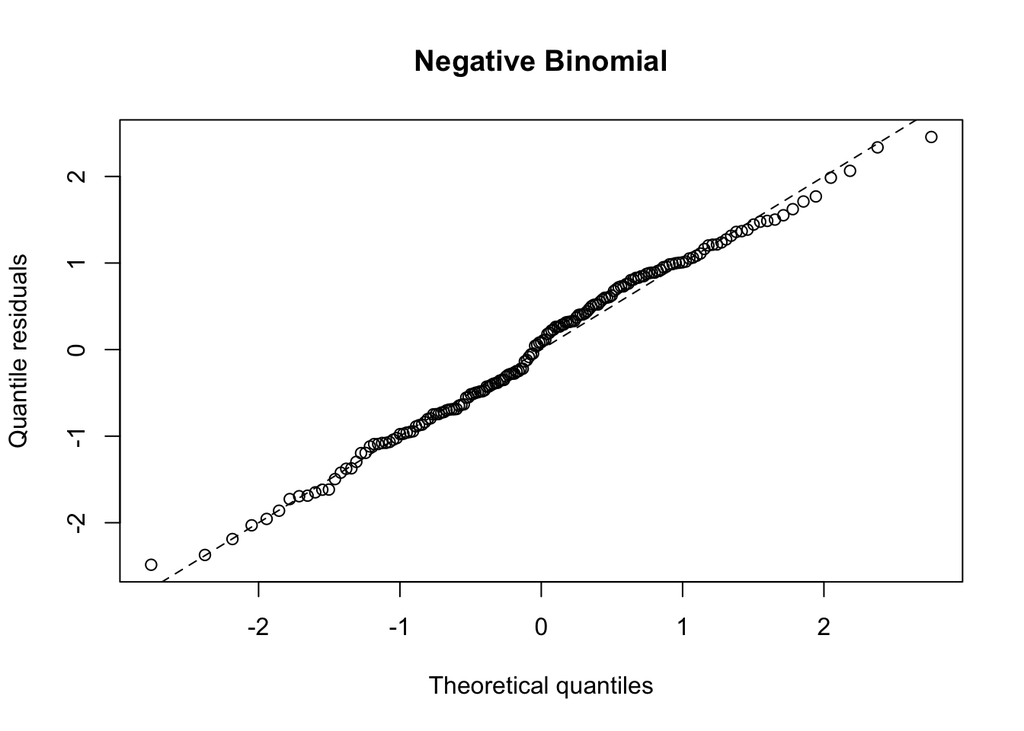

```r
# QQ-plot for negative binomial
qqrplot(nb_mod,
        main = "Negative Binomial")
```

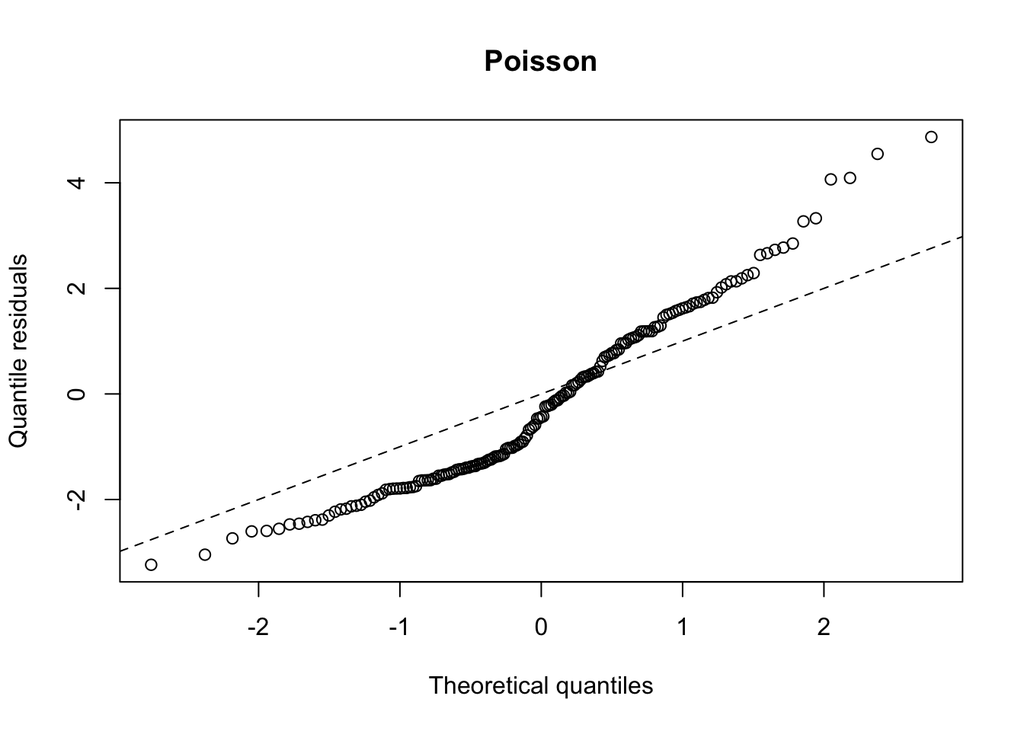

```r
# Compare with the Poisson fit
qqrplot(pois_mod_2,
        main = "Poisson")
```

## Extra questions

If you did all the above and have time to spare, try these:

1. Another data set which is worth fitting a linear regression model to is the `geese_isotopes.csv` data. You might like to see if one of the isotope values is affected by some of the other variables (sex, adult, etc)
2. The whitefly data set. This is binomial (as used in the lectures) but you might like to additionally try some of the other variables and see which are important and why. The data set has particular issues with zero-inflation. See if you can find which zero data points are poorly predicted by the model.